# Monthly pension returns analysis: Velliv June 2012 - April 2024

## Convergence

### Max vs sum

Max-vs-sum plots for the first four moments – a ratio that doesn’t fall toward zero flags that moment as possibly non-existent (see “Max-sum plots” in the comparison report for what this diagnostic tests). Panels by fitted distribution:

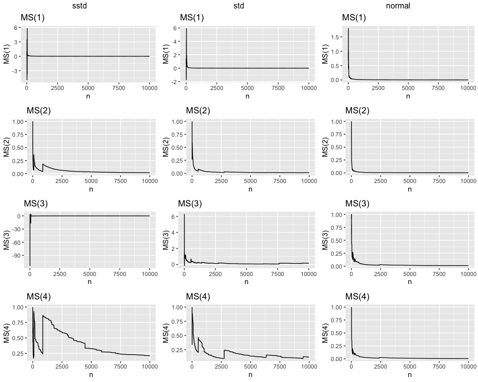

### MC

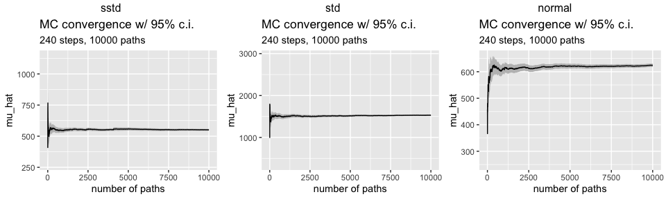

### IS

Skewed $t$-distribution with a normal proposal distribution.

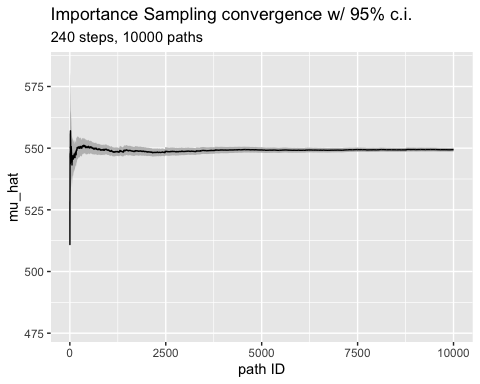

Parameters

```
## [1] 1.8343283 0.5082016
```

Objective function plots

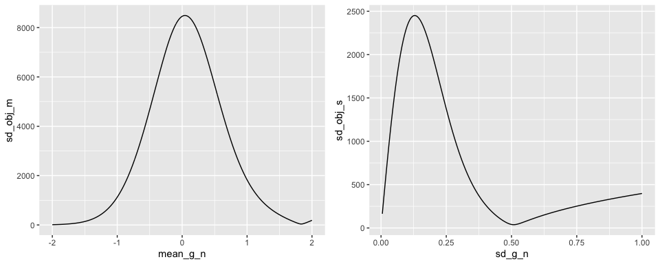

# PFA medium risk (pmr), June 2012 - April 2024

## QQ Plot

Skewed $t$-distribution (sstd):

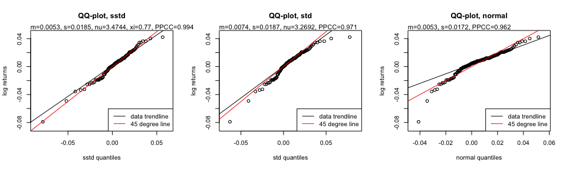

## Data vs fit

Let’s plot the fit and the observed returns together.

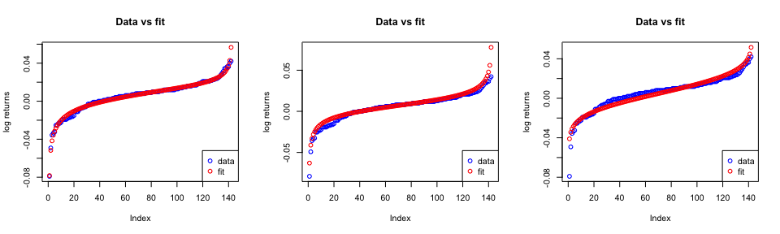

## Estimated distribution

Now lets look at the CDF of the estimated distribution for each 0.1% increment between 0.5% and 99.5% for the estimated distribution:

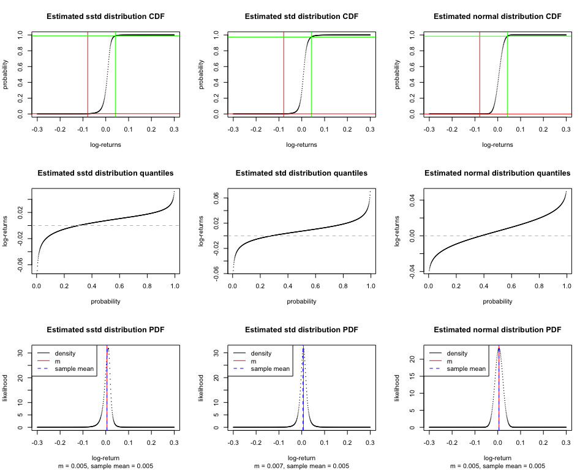

## Monte Carlo

Sorted portfolio index values for last period of all runs

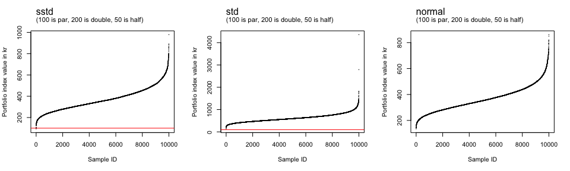

## Convergence

### Max vs sum

Max-vs-sum plots for the first four moments – a ratio that doesn’t fall toward zero flags that moment as possibly non-existent (see “Max-sum plots” in the comparison report for what this diagnostic tests). Panels by fitted distribution:

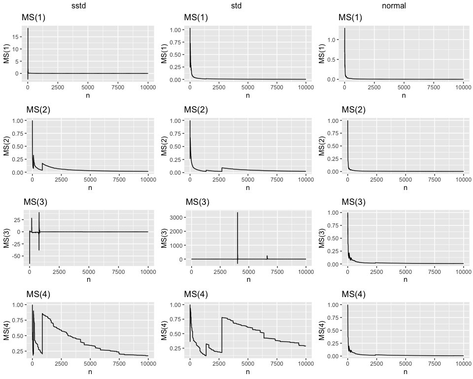

### MC

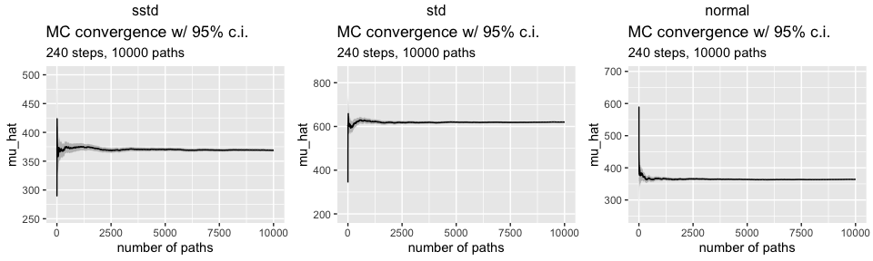

### IS

Skewed $t$-distribution with a normal proposal distribution.

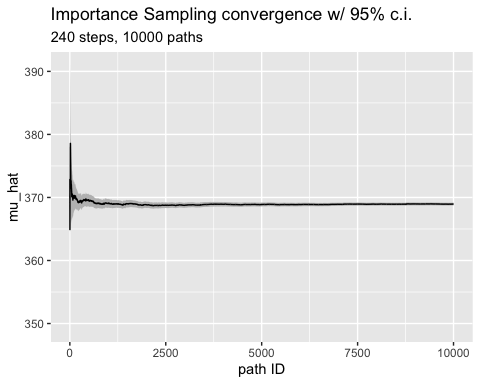

Parameters

```
## [1] 1.3478515 0.2887121
```

Objective function plots

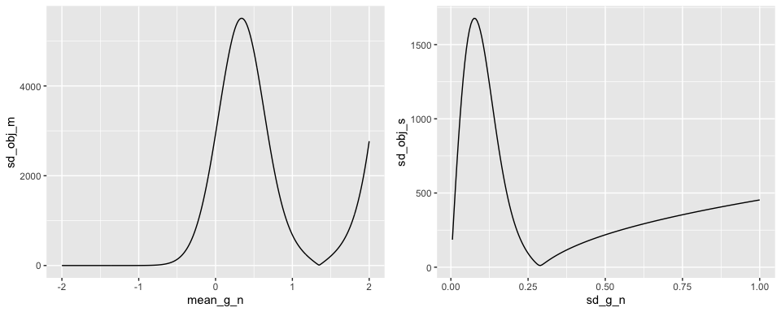

# PFA high risk (phr), June 2012 - April 2024

## QQ Plot

Skewed $t$-distribution (sstd):

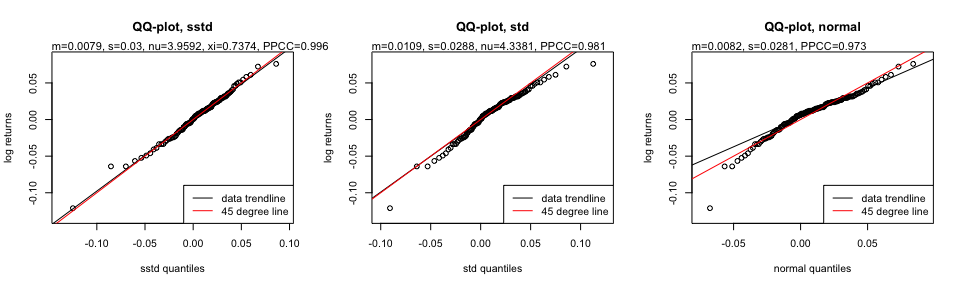

## Data vs fit

Let’s plot the fit and the observed returns together.

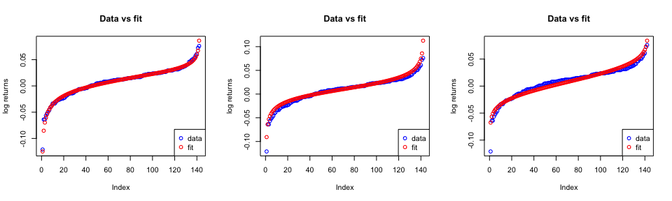

## Estimated distribution

Now lets look at the CDF of the estimated distribution for each 0.1% increment between 0.5% and 99.5% for the estimated distribution:

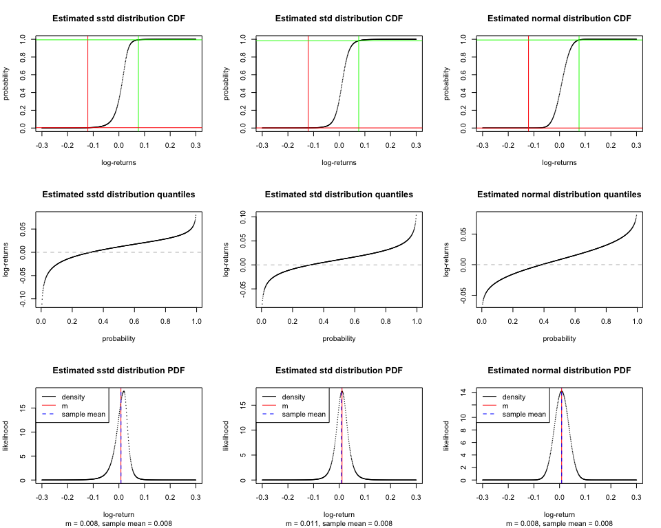

## Monte Carlo

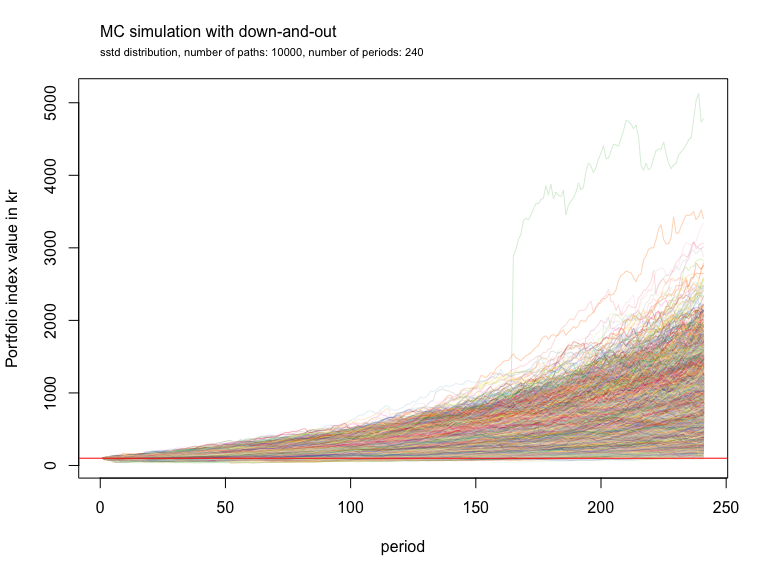

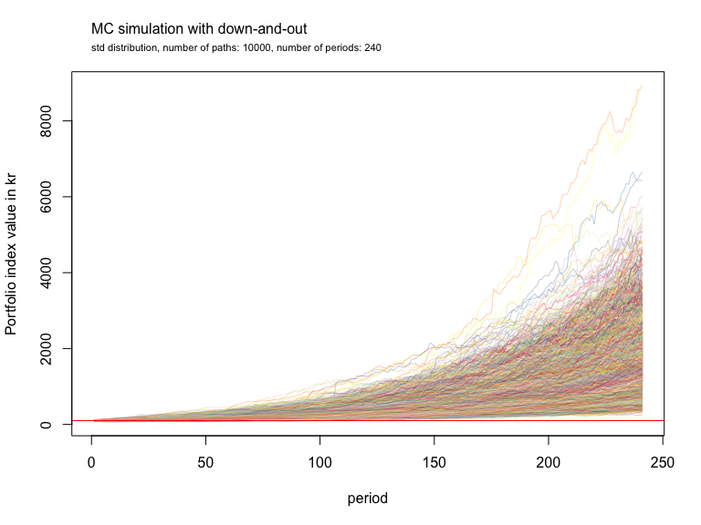

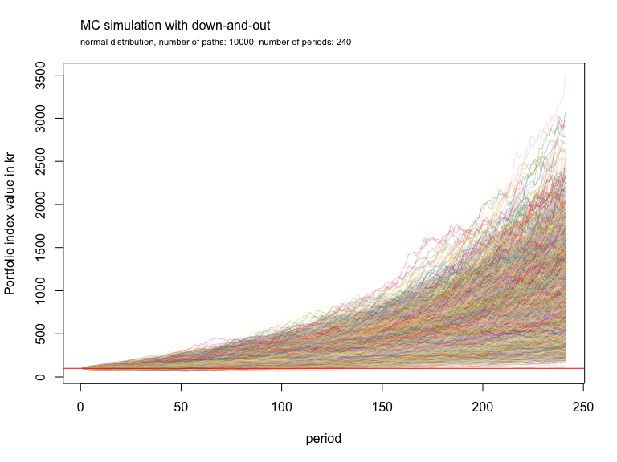

Sorted portfolio index values for last period of all runs

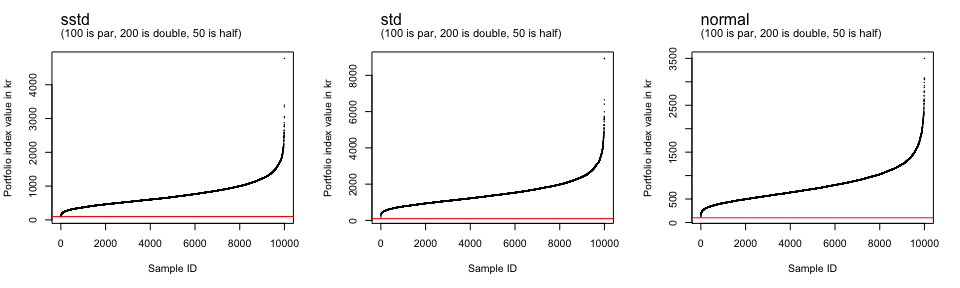

## Convergence

### Max vs sum

Max-vs-sum plots for the first four moments – a ratio that doesn’t fall toward zero flags that moment as possibly non-existent (see “Max-sum plots” in the comparison report for what this diagnostic tests). Panels by fitted distribution:

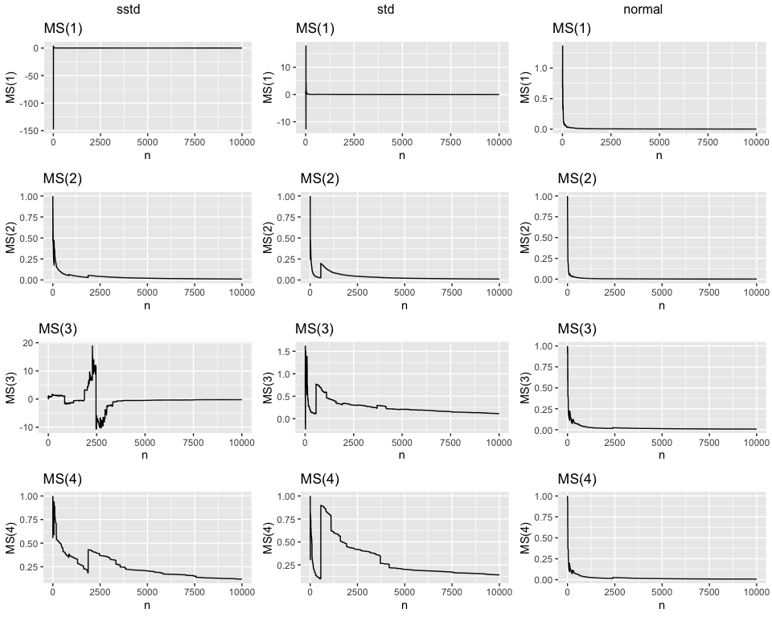

### MC

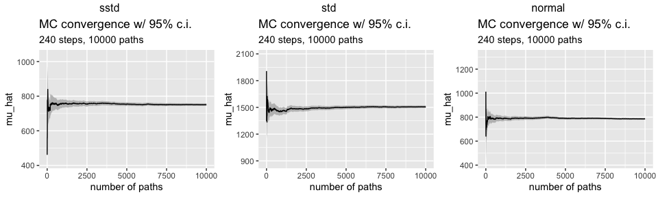

### IS

Skewed $t$-distribution with a normal proposal distribution.

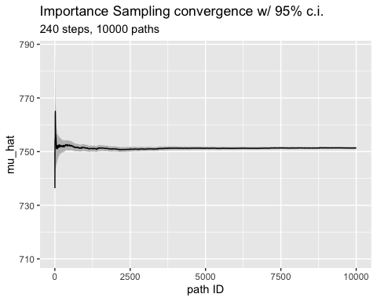

Parameters

```
## [1] 2.1231707 0.4591479
```

Objective function plots

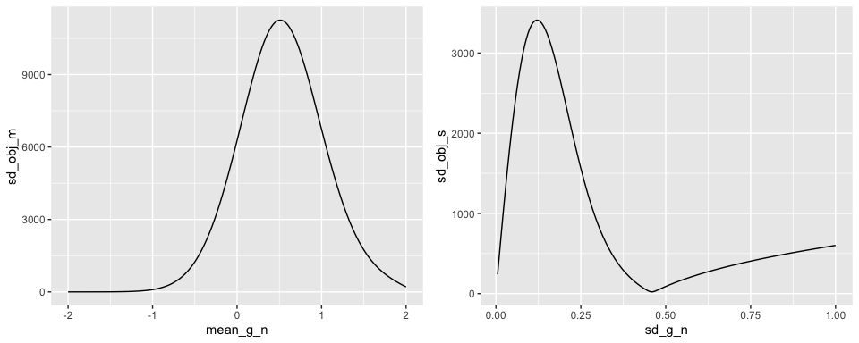

# Mix medium risk (mmr), June 2012 - April 2024

## QQ Plot

Skewed $t$-distribution (sstd):

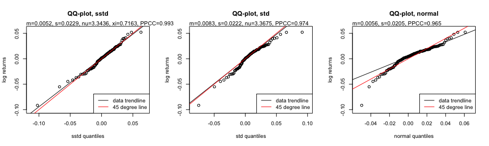

## Data vs fit

Let’s plot the fit and the observed returns together.

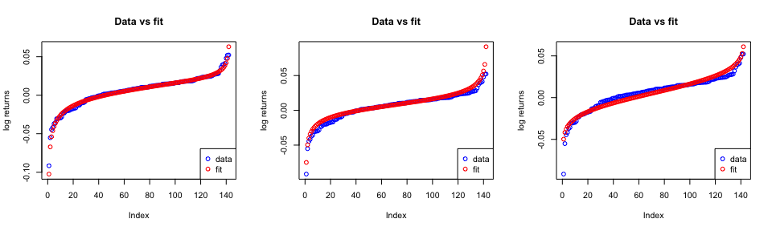

## Estimated distribution

Now lets look at the CDF of the estimated distribution for each 0.1% increment between 0.5% and 99.5% for the estimated distribution:

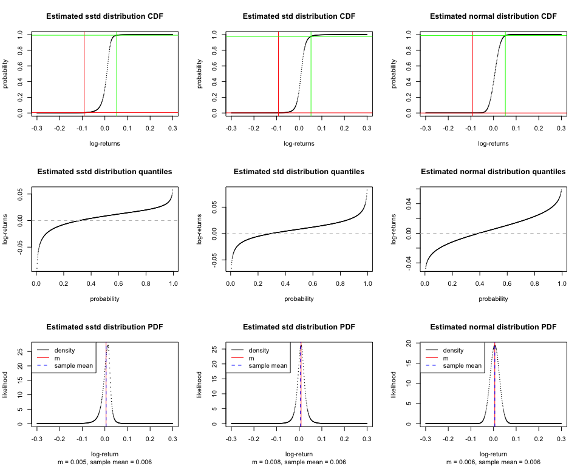

## Monte Carlo

mmr has the sstd fit with the lowest value of nu. Compare with other distributions:

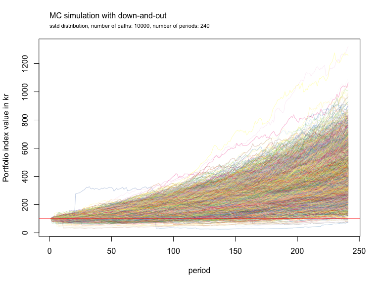

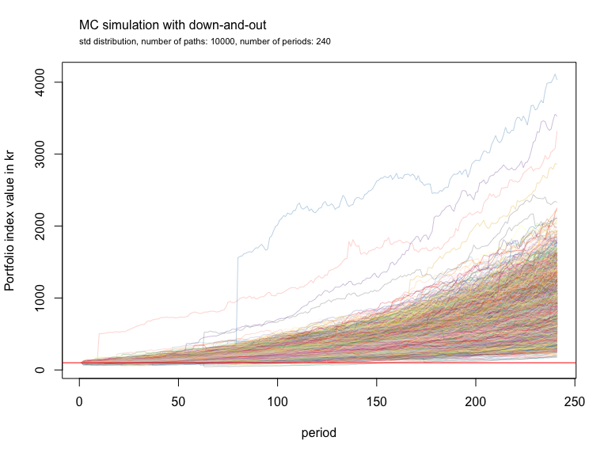

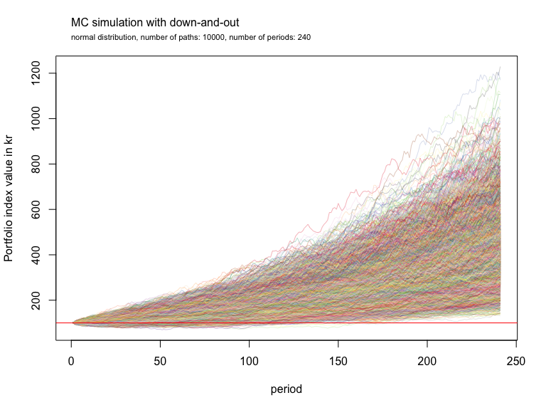

Sorted portfolio index values for last period of all runs

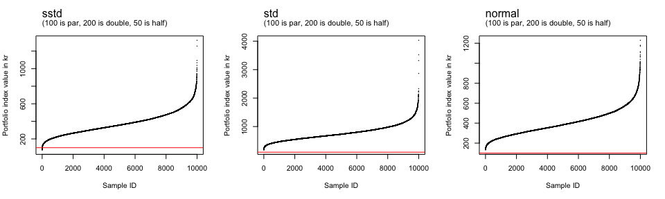

## Convergence

### Max vs sum

Max-vs-sum plots for the first four moments – a ratio that doesn’t fall toward zero flags that moment as possibly non-existent (see “Max-sum plots” in the comparison report for what this diagnostic tests). Panels by fitted distribution:

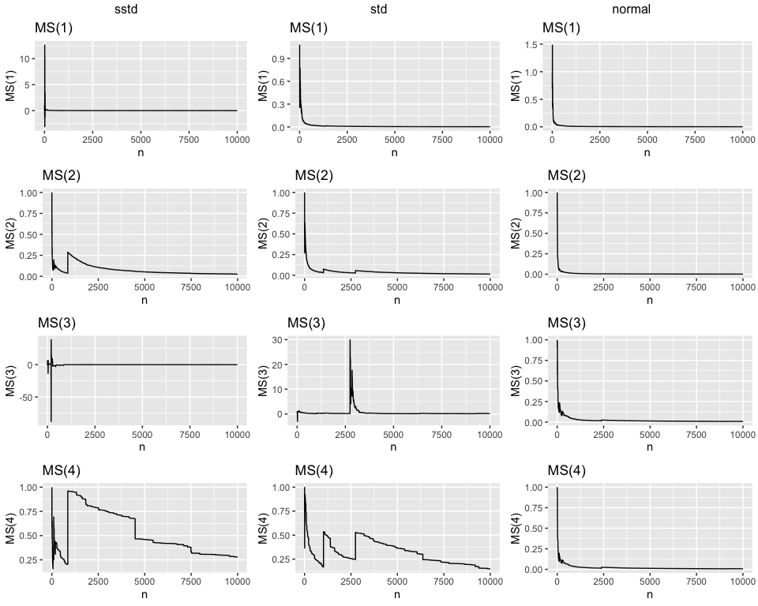

### MC

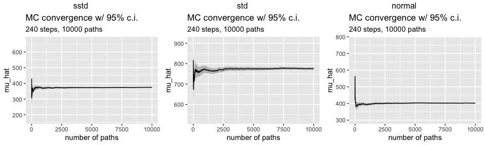

### IS

Skewed $t$-distribution with a normal proposal distribution.

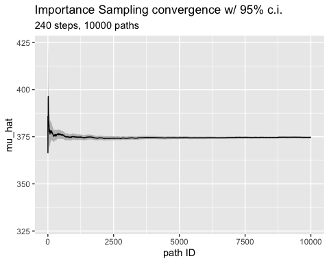

Parameters

```
## [1] 1.3801769 0.3404913
```

Objective function plots

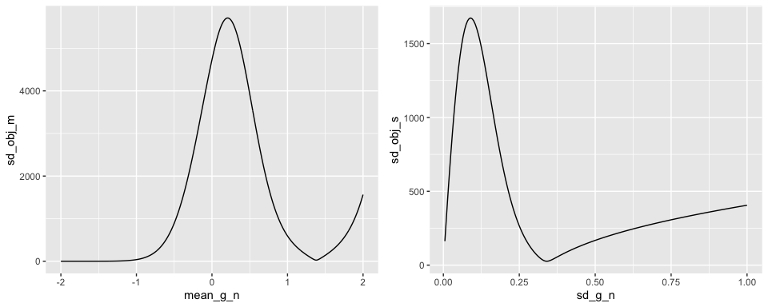

# Mix high risk (mhr), June 2012 - April 2024

## QQ Plot

Skewed $t$-distribution (sstd):

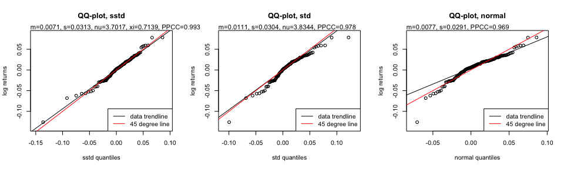

## Data vs fit

Let’s plot the fit and the observed returns together.

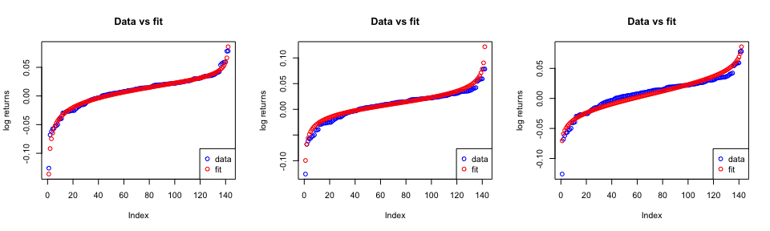

## Estimated distribution

Now lets look at the CDF of the estimated distribution for each 0.1% increment between 0.5% and 99.5% for the estimated distribution:

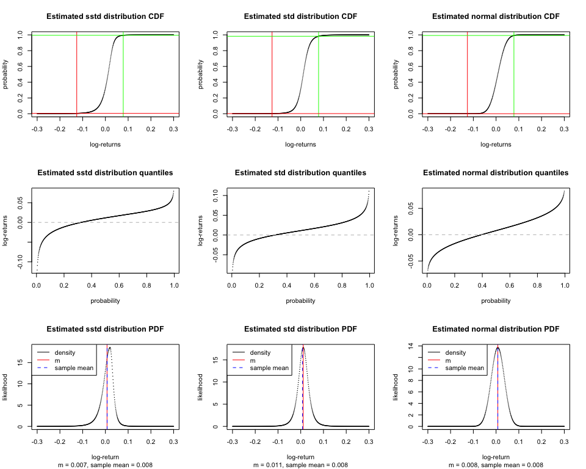

## Monte Carlo

Sorted portfolio index values for last period of all runs

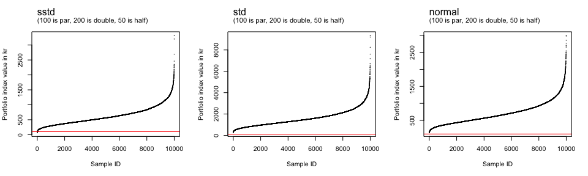

## Convergence

### Max vs sum

Max-vs-sum plots for the first four moments – a ratio that doesn’t fall toward zero flags that moment as possibly non-existent (see “Max-sum plots” in the comparison report for what this diagnostic tests). Panels by fitted distribution:

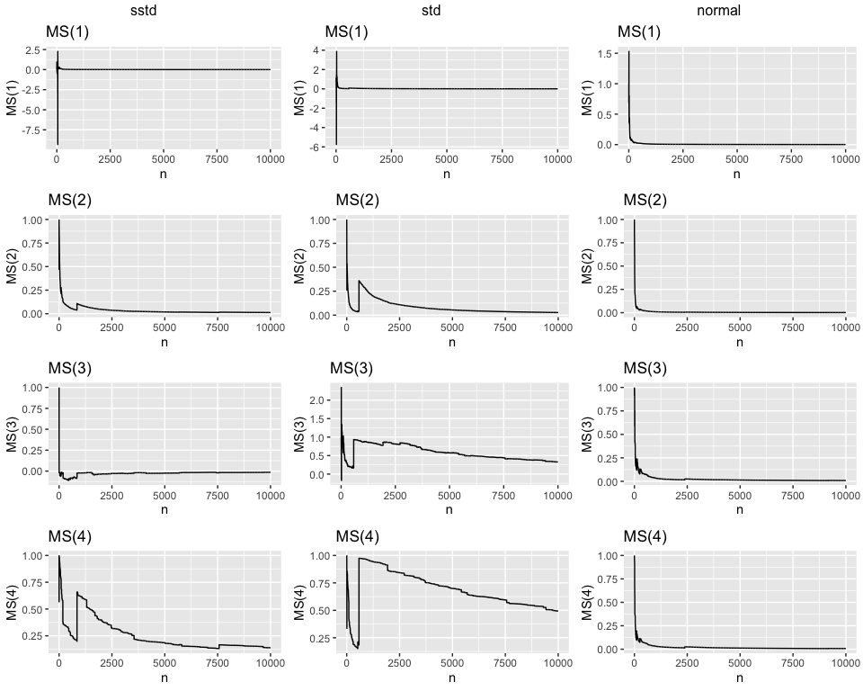

### MC

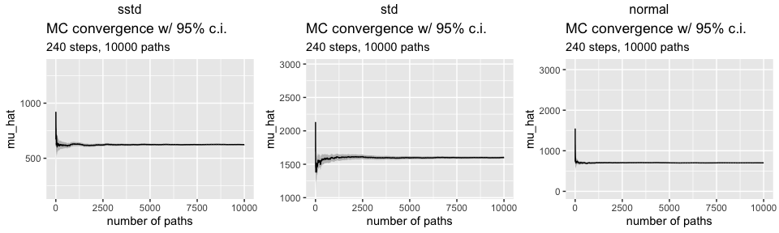

### IS

Skewed $t$-distribution with a normal proposal distribution.

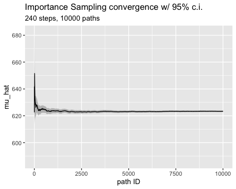

Parameters

```
## [1] 1.9450423 0.4749438
```

Objective function plots

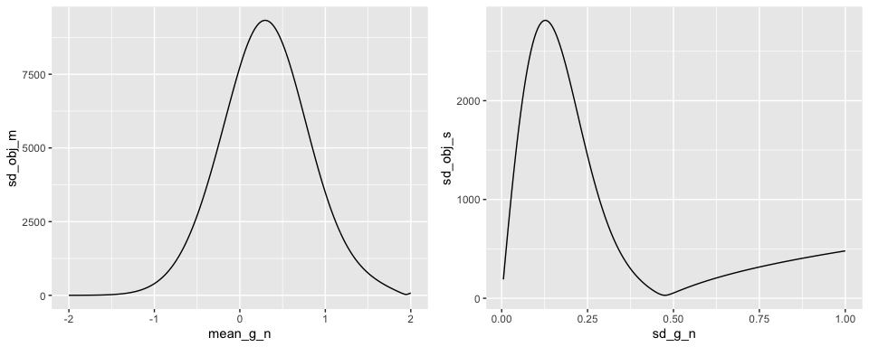

# Mix vmr+phr (vm_ph), June 2012 - April 2024

## QQ Plot

Skewed $t$-distribution (sstd):

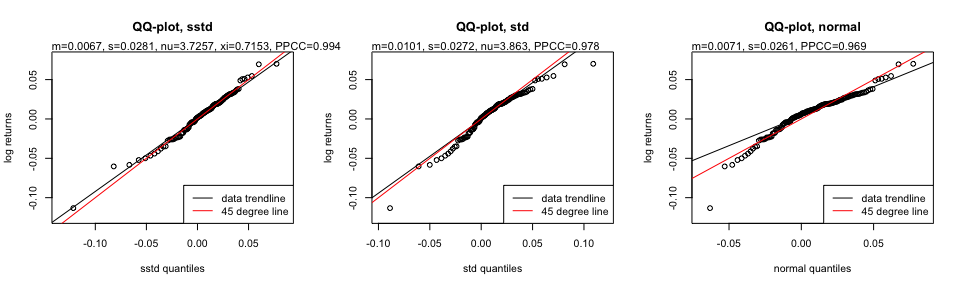

## Data vs fit

Let’s plot the fit and the observed returns together.

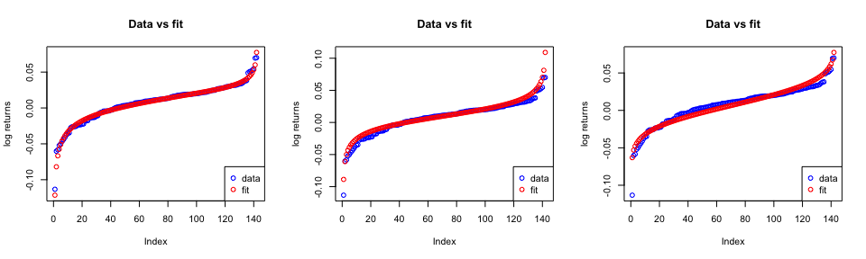

## Estimated distribution

Now lets look at the CDF of the estimated distribution for each 0.1% increment between 0.5% and 99.5% for the estimated distribution:

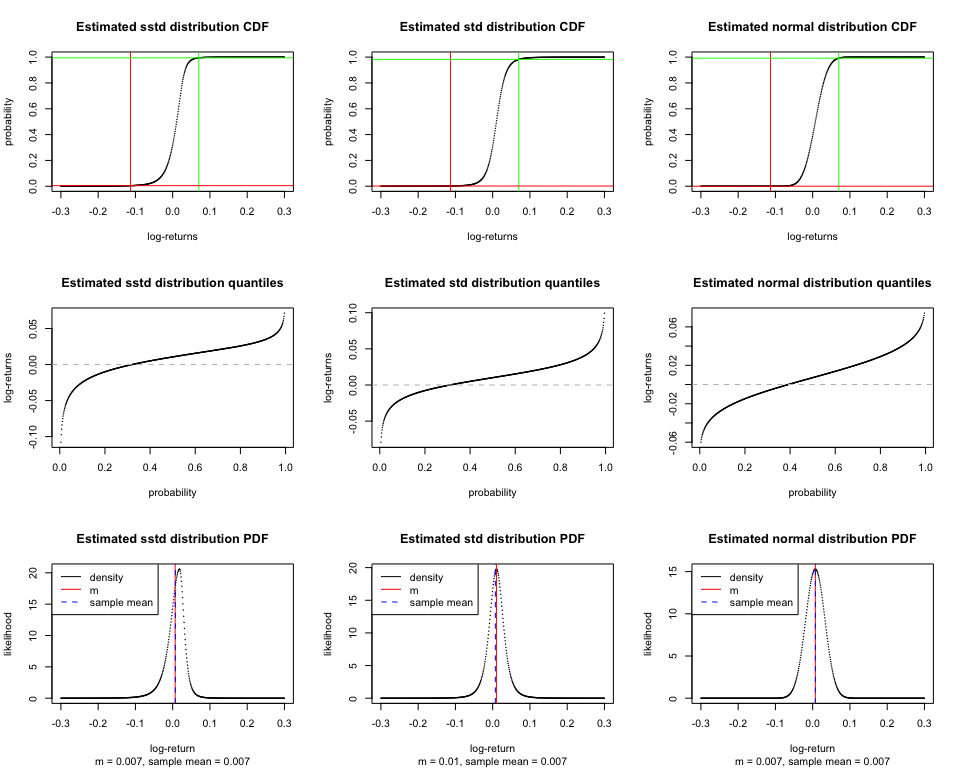

## Monte Carlo

Sorted portfolio index values for last period of all runs

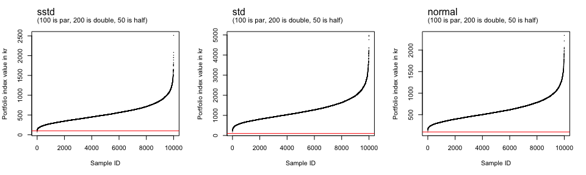

## Convergence

### Max vs sum

Max-vs-sum plots for the first four moments – a ratio that doesn’t fall toward zero flags that moment as possibly non-existent (see “Max-sum plots” in the comparison report for what this diagnostic tests). Panels by fitted distribution:

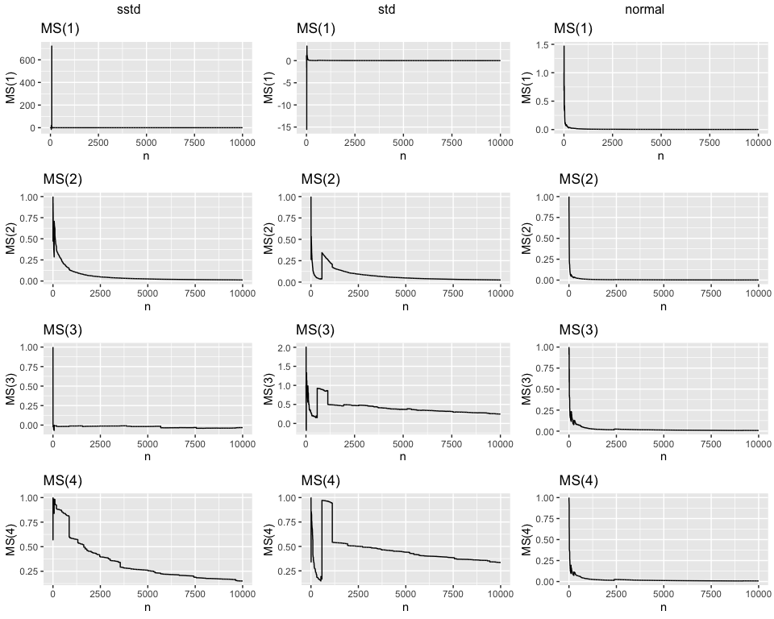

### MC

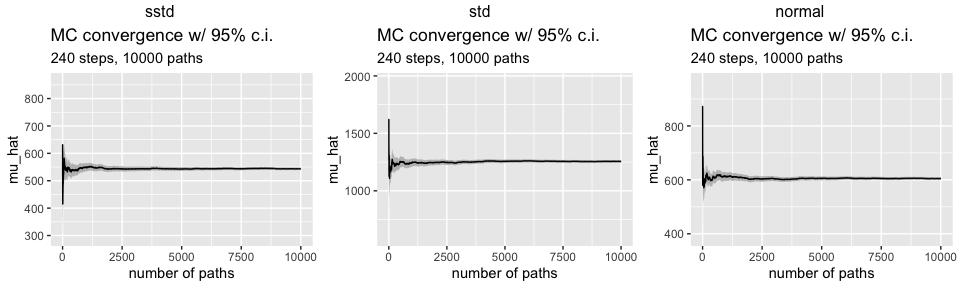

### IS

Skewed $t$-distribution with a normal proposal distribution.

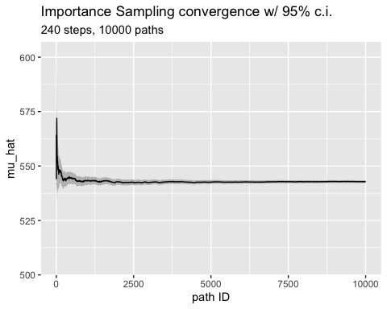

Parameters

```
## [1] 1.7833719 0.4233113
```

Objective function plots

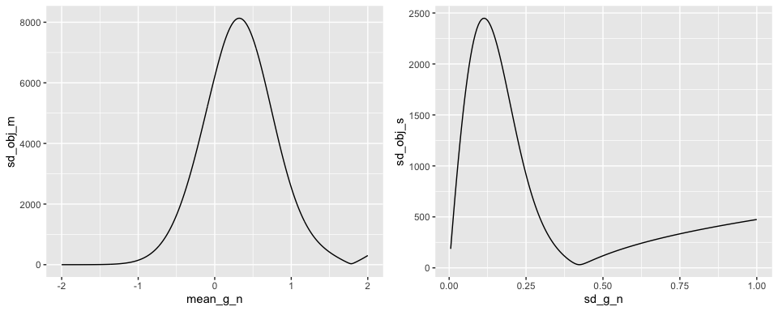

# Mix vhr+pmr (mh_pm), June 2012 - April 2024

## QQ Plot

Skewed $t$-distribution (sstd):

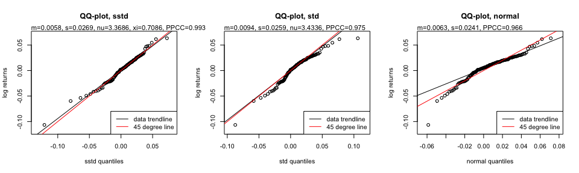

## Data vs fit

Let’s plot the fit and the observed returns together.

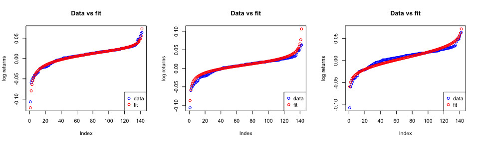

## Estimated distribution

Now lets look at the CDF of the estimated distribution for each 0.1% increment between 0.5% and 99.5% for the estimated distribution:

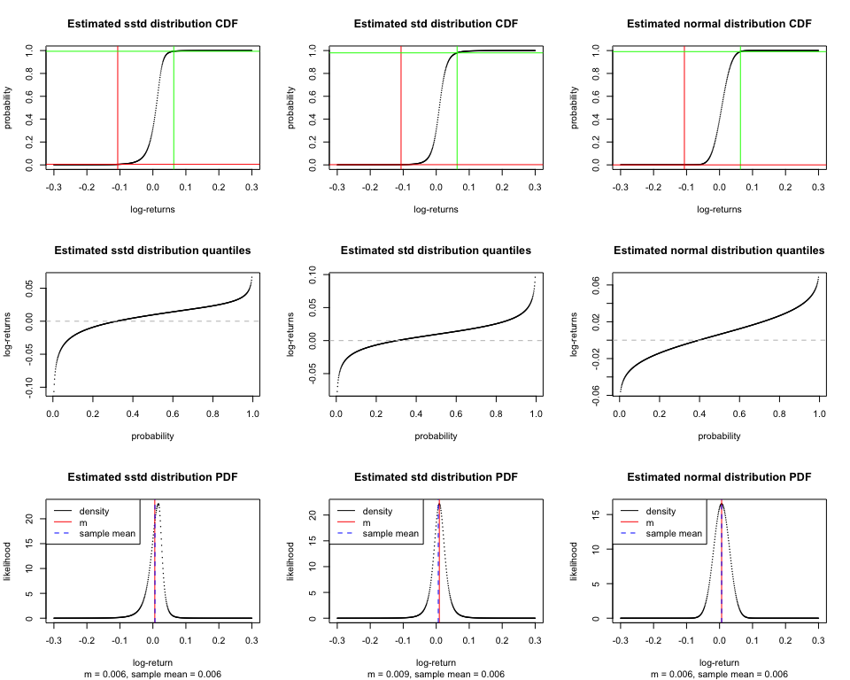

## Monte Carlo

Sorted portfolio index values for last period of all runs

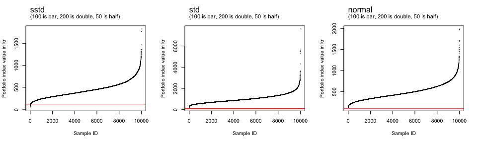

## Convergence

### Max vs sum

Max-vs-sum plots for the first four moments – a ratio that doesn’t fall toward zero flags that moment as possibly non-existent (see “Max-sum plots” in the comparison report for what this diagnostic tests). Panels by fitted distribution:

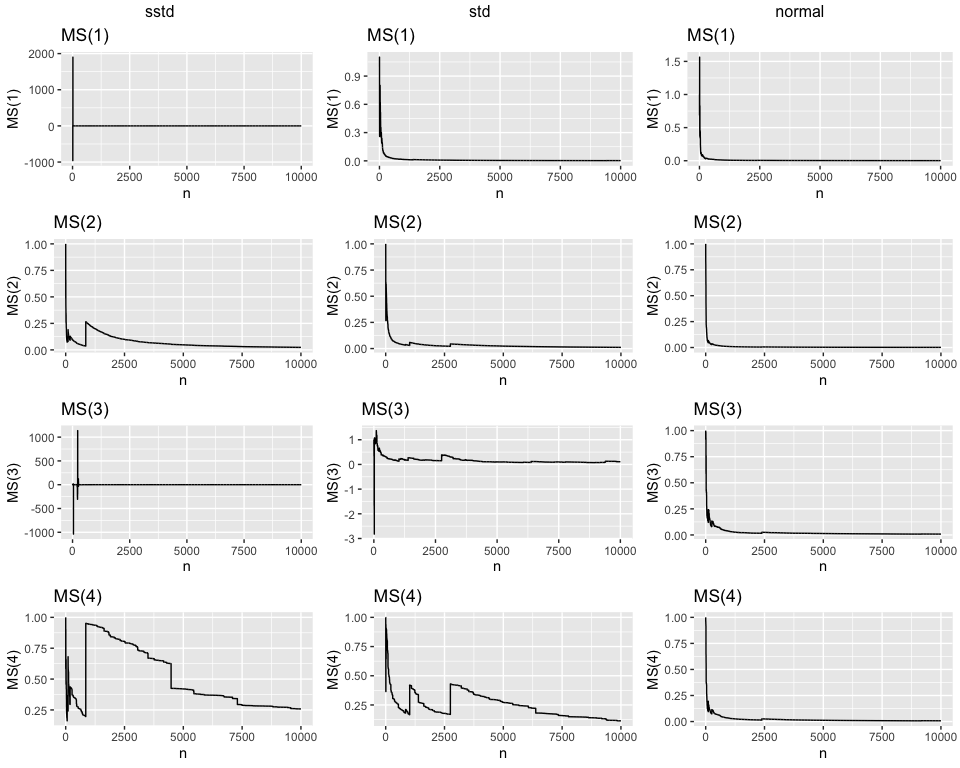

### MC

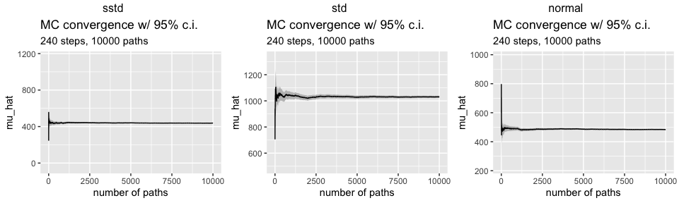

### IS

Skewed $t$-distribution with a normal proposal distribution.

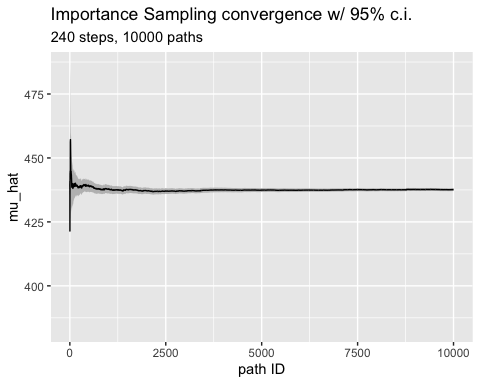

Parameters

```
## [1] 1.560453 0.406833
```

Objective function plots

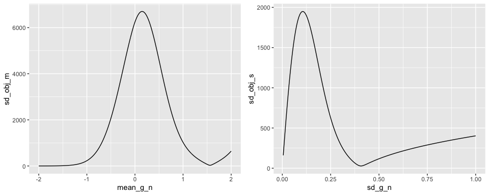